# draft

*Azospirillum brasilense* **as a bioinoculant to alleviate salinity effects on quinoa seed germination**

Jose David Apaza-Calcina1,2*, Milagros Ninoska Munoz-Salas3, Flavio Lozano-Isla4,5, Rachel Passos Rezende1,6, Raner José Santana Silva6

1Laboratório de Biotecnologia Microbiana, Centro de Biotecnologia e Genética, Universidade Estadual de Santa Cruz, Campus Soane Nazaré de Andrade, Rodovia Jorge Amado, km 16, Bairro Salobrinho, 45662-900, Ilhéus, Bahia, Brasil.

2Dirección de Recursos Genéticos y Biotecnología, Estación Experimental Agraria Perla del Vraem, Instituto Nacional de Innovación Agraria (INIA), Cusco 00800, Perú.

3Department of Earth and Environment, Institute of Environment, Florida International University, Miami, FL 33199, USA

4Facultad de Ingeniería y Ciencias Agrarias, Universidad Nacional Toribio Rodríguez de Mendoza de Amazonas (UNTRM), Amazonas 01001, Perú.

5Dirección de Supervisión y Monitoreo en las Estaciones Experimentales - Estación Experimental Agraria El Chira, Instituto Nacional de Innovación Agraria (INIA), Piura 20120, Perú.

6Programa de Pós-graduação em Genética e Biologia Molecular, Universidade Estadual de Santa Cruz, Campus Soane Nazaré de Andrade, Rodovia Jorge Amado, km 16, Bairro Salobrinho, 45662-900, Ilhéus, Bahia, Brasil.

*Corresponding authors: jdacalcina@uesc.br

**ORCID IDs:**

Jose David Apaza-Calcina: 0000-0001-6198-0530

Milagros Ninoska Munoz-Salas: 0009-0001-7278-5690

Flavio Lozano-Isla: 0000-0002-0714-669X

Rachel Passos Rezende: 0000-0003-2969-6788

Raner Santana: 0000-0002-0805-2003

**Abstract**

Quinoa (*Chenopodium quinoa* Willd.) is a climate-resilient crop valued for its superior nutritional quality and adaptability to marginal soils. Despite its tolerance to abiotic stress, the early developmental stages - particularly germination and seedling establishment - are highly sensitive to salinity. This study evaluated the capacity of two halotolerant strains of *Azospirillum brasilense* (BR-11001 and BR-11002) to enhance salt stress tolerance in the quinoa cultivar ‘BRS Piabiru.’ A 3 × 4 factorial design in a completely randomized design with three strain treatments and four NaCl concentrations (0, 150, 300, and 450 mM), with four replicates per treatment. Seeds were surface sterilized, inoculated, and incubated at 18 °C under constant light for 10 days. Elevated salinity (≥300 mM NaCl) significantly reduced germination and seedling vigor in uninoculated controls. In contrast, BR-11002 notably alleviated salinity-induced damage, sustaining over 84% germination at 450 mM and improving seedling biomass and vigor at 300 mM. These results demonstrate the potential of BR-11002 as a biostimulant to promote quinoa performance under saline conditions. Its use represents a strategy for sustainable agriculture in salt-affected areas, supporting crop productivity and food system resilience amid increasing soil salinization.

**Keywords:** plant growth-promoting bacteria (PGPB), salinity stress, seed science, seedling growth, sodium chloride, sustainable agriculture.

# **Introduction**

Salinity has emerged as a pressing global challenge that increasingly threatens agricultural sustainability. Estimates from the Food and Agriculture Organization [(FAO, 2021)](https://www.zotero.org/google-docs/?VF45TA) indicate that more than 900 million hectares of land worldwide are affected by salt accumulation, including nearly one-fifth of all irrigated lands. This widespread salinization is largely driven by poor irrigation management, limited drainage infrastructure, and intensifying climate variability, particularly in arid and semi-arid ecosystems where evapotranspiration surpasses precipitation rates [(Shrivastava and Kumar, 2015)](https://www.zotero.org/google-docs/?wDqhpO). Saline stress disrupts plant physiological processes through osmotic imbalance, ion toxicity - primarily from Na⁺ and Cl⁻ - and the excessive generation of reactive oxygen species (ROS), which collectively impair germination, limit root growth, and hinder crop performance [(Zörb, Geilfus and Dietz, 2019)](https://www.zotero.org/google-docs/?FonkRA).

Quinoa (*Chenopodium quinoa* Willd.) has garnered increasing attention as a climate-resilient crop due to its high nutritional quality and ability to tolerate adverse agroecological conditions [(Bazile, Jacobsen and Verniau, 2016)](https://www.zotero.org/google-docs/?kmAs0Y). Although quinoa demonstrates moderate salt tolerance during vegetative growth, its early developmental stages - particularly seed germination and seedling establishment - are highly sensitive to elevated NaCl levels [(Causin, Bordón and Burrieza, 2020)](https://www.zotero.org/google-docs/?pbzOcw). Delayed emergence and uneven seedling vigor are commonly observed in saline soils, thereby limiting crop stand uniformity and yield potential [(Mougiou *et al.*, 2018)](https://www.zotero.org/google-docs/?7tGvVk). Enhancing salt tolerance during these critical early phases is essential for enabling quinoa cultivation in salt-affected marginal environments.

In this context, plant growth-promoting bacteria (PGPB) represent a promising and environmentally sustainable strategy to support crop establishment under saline conditions. PGPB contribute to plant resilience through diverse mechanisms, including biological nitrogen fixation, phosphate solubilization, siderophore production, and the synthesis of growth-promoting hormones such as indole-3-acetic acid (IAA). They also activate antioxidant defense systems that mitigate ROS-induced oxidative damage [(Egamberdieva *et al.*, 2017)](https://www.zotero.org/google-docs/?nFg204). Among the PGPB genera, *Azospirillum brasilense* has been extensively studied for its beneficial effects on root system development, nutrient assimilation, and biomass accumulation under abiotic stress, particularly in cereal and pseudocereal crops [(Hungria *et al.*, 2010)](https://www.zotero.org/google-docs/?x463g9).

Recent efforts have focused on halotolerant and extremophilic bacterial strains isolated from saline soils, which exhibit enhanced potential to confer salt tolerance in crops such as wheat, rice, and soybean [(Khumairah *et al.*, 2022; Santos *et al.*, 2023)](https://www.zotero.org/google-docs/?hZ1NLu). These microorganisms promote seedling vigor and germination under salinity by improving ion homeostasis, limiting lipid peroxidation, and elevating antioxidant enzyme activity [(Kerbab *et al.*, 2021)](https://www.zotero.org/google-docs/?NtEDsJ). Nevertheless, limited research has examined the effects of *A. brasilense* strains on quinoa performance under saline stress, leaving a gap in understanding their potential applications in quinoa-based cropping systems.

To address this gap, the present study was designed to investigate the role of halotolerant *A. brasilense* strains in alleviating salinity stress during the early growth stages of *C. quinoa*. Specifically, the study pursued four objectives: (i) to evaluate the growth potential of six bacterial strains under saline and non-saline media to assess viability and salt tolerance; (ii) to assess the impact of a NaCl concentration gradient (0-450 mM) on seed germination and cotyledon emergence as indicators of inoculation efficacy; (iii) to determine the influence of inoculation on seedling morphometric parameters - such as shoot and root length and dry weight - under saline stress; and (iv) to examine physiological stress responses by quantifying the activity of key antioxidant enzymes.

# **Materials and Methods**

## *Biological materials and bacterial strains*

A total of six *Azospirillum brasilense* strains - BR-11001, BR-11002, BR-11003, BR-11004, BR-11005, and BR-11006 - were provided by the Brazilian Agricultural Research Corporation (EMBRAPA). These strains were previously characterized for their salt tolerance and plant growth-promoting activity, including their ability to produce phytohormones, enhance nutrient absorption, and alleviate oxidative stress under saline conditions [(Reis *et al.*, 2001; Omar *et al.*, 2009; Da Cunha, Pedrolo and Arisi, 2024)](https://www.zotero.org/google-docs/?nZGtJM).

Seeds of *Chenopodium quinoa* Willd. cultivar ‘BRS Piabiru’ was obtained from the EMBRAPA germplasm collection. This genotype is adapted to tropical and subtropical climates and is recognized for its early maturation, high productivity, and resilience to biotic and abiotic stresses [(de Oliveira Vergara *et al.*, 2019)](https://www.zotero.org/google-docs/?AxRAJg)). Furthermore, it exhibits high phenolic content - including quercetin and kaempferol derivatives - contributing to its antioxidant potential and stress tolerance [(Sampaio *et al.*, 2020)](https://www.zotero.org/google-docs/?nXLemK). This cultivar was chosen to assess physiological responses to salt stress and evaluate the potential benefits of microbial inoculation.

## *Evaluation of salinity tolerance in A. brasilense strains*

To assess halotolerance, each of the six *A. brasilense* strains was cultured in Luria–Bertani (LB) broth containing a gradient of sodium chloride concentrations (0, 150, 300, 450, 600, 750, and 900 mM NaCl). Initial inocula were standardized to an optical density (OD₆₀₀) of 0.1 and incubated in 10 mL of LB medium at 35 °C for 48 hours, shaking at 200 rpm. Bacterial growth was quantified spectrophotometrically by recording optical density at 600 nm (OD₆₀₀) using a Rayleigh UV–Vis spectrophotometer (Rayleigh Instruments, China). Additionally, bacterial viability was estimated by serial dilution and plating on nutrient agar supplemented with corresponding NaCl concentrations. Colony-forming units (CFU) were enumerated after 48 hours of incubation. All experiments were conducted in triplicate.

## *Inoculum preparation and seed treatment*

Following the salinity assay, the *A. brasiliense* strains BR-11001 (rhizospheric) and BR-11002 (endophytic) were selected for further experiments due to their superior growth performance under saline conditions. These strains were individually cultured in 250 mL of LB broth at 35 °C for 24 hours using an orbital shaker (PsycroTherm, New Brunswick Scientific, USA) at 120 rpm. Bacterial cells were harvested by centrifugation (5,000 × g, 10 minutes) and resuspended in sterile distilled water. The final suspension was adjusted to OD₆₀₀ = 0.400, corresponding to an approximate density of 10⁸ CFU/mL.

Quinoa seeds were disinfected by immersion in 75% ethanol for 1 minute, followed by treatment with 2% sodium hypochlorite for 2 minutes. Seeds were then rinsed thoroughly three times with sterile distilled water. For inoculation, sterilized seeds were soaked in the bacterial suspension for 45 minutes at 25°C, following the methodology outlined by Barbieri et al. [(Barbieri *et al.*, 2019)](https://www.zotero.org/google-docs/?yLeBr3).

## *Germination assay under salinity stress*

The germination experiment was structured as a completely randomized block design (CRBD) within a 3 × 4 factorial framework, incorporating three inoculation treatments - *A. brasilense* BR-11001, BR-11002, and a non-inoculated control - and four sodium chloride (NaCl) levels: 0, 150, 300, and 450 mM. This resulted in 12 treatment combinations, each replicated four times using 50 seeds per replicate. Seeds were sown on germination paper moistened with NaCl solution at a volume equal to 2.5 times the dry weight of the paper and enclosed in seed germination boxes [(Costa *et al.*, 2024; Dias *et al.*, 2025)](https://www.zotero.org/google-docs/?7oa7ca). The germination process was carried out in a growth chamber set at 18 °C for a period of 10 days. On the fourth day, rehydration was performed using the respective saline solution.

Daily observations were made to monitor radicle emergence, with germination considered effective when the radicle extended at least 2 mm, following the International Rules for Seed Testing [(ISTA, 2022)](https://www.zotero.org/google-docs/?4auGmq). To quantify germination performance and seed vigor, the following indices were calculated: Germination Percentage (GP), Mean Germination Time (MGT), Synchronization Index (SYN), and Uncertainty Index (UNC). These metrics were derived using the equations described by Ranal and Santana [(Ranal and Santana, 2006)](https://www.zotero.org/google-docs/?CC48Yc) and implemented in the GerminaR R package [(Lozano‐Isla, Benites‐Alfaro and Pompelli, 2019)](https://www.zotero.org/google-docs/?R5SEr5).

*Seedling growth evaluation*

Seedling morphometric measurements were collected 10 days after sowing to assess early-stage biomass accumulation and physiological performance under saline stress conditions. Shoot and root lengths were recorded in centimeters, while dry biomass was determined in grams after drying the seedlings in a forced-air oven at 65 °C until a constant weight was achieved. The seedling vigor index (SVI) was used as an integrative metric to assess early plant development under stress conditions by combining seed germination capacity and seedling growth performance [(Zhao, Joo and Kim, 2021)](https://www.zotero.org/google-docs/?FUBnu7). The SVI was calculated using the formula:

$$\text{SVI} = (\overline{L_r} + \overline{L_s}) \times \overline{GP}$$

Where $\overline{L_r}$ is the mean root length, expressed in centimeters (cm), and $\overline{L_s}$ is the mean shoot length, also expressed in centimeters. The term $\overline{GP}$ represents the average germination percentage of the seeds, expressed as a percentage (%).

*Antioxidant enzyme activity assays*

The activities of four key antioxidant enzymes - superoxide dismutase (SOD), catalase (CAT), ascorbate peroxidase (APX), and guaiacol peroxidase (GPX) - were determined in ten-day-old *Chenopodium quinoa* seedlings to evaluate their response to oxidative stress induced by salinity. For enzyme extraction, 0.1 grams of fresh plant tissue was homogenized in 1.5 milliliters of ice-cold extraction buffer (50 mM potassium phosphate, pH 7.0; 1 mM EDTA; and 1% polyvinylpyrrolidone [PVP]). The homogenate was centrifuged at 12,000 rpm for 15 minutes at 4 °C, and the supernatant was collected for subsequent enzymatic assays. Protein concentration was determined using the Bradford method (Bradford, 1976). All enzymatic analyses were performed at 25 °C, following adaptations of the protocols described by Sinha et al. [(Siṃha, Sinha and Häder, 2024)](https://www.zotero.org/google-docs/?xnEynI).

SOD activity was evaluated using a method adapted from Beyer and Fridovich (1987), which is based on the enzyme’s ability to inhibit the photochemical reduction of nitroblue tetrazolium (NBT). The reaction mixture (3.0 mL) included 50 mM potassium phosphate buffer (pH 7.8), 13 mM methionine, 75 µM NBT, 2 µM riboflavin, 100 µM EDTA, 50 mM sodium carbonate (pH 10.2), and 100 µL of enzymatic extract. The reaction was initiated by adding riboflavin and exposing the tubes to white fluorescent light (80–100 µmol photons m⁻² s⁻¹) for 15 minutes. A control group was kept in darkness. Formazan formation was evaluated by measuring absorbance at 560 nm. SOD activity was expressed as the percentage inhibition of NBT reduction compared to a control without enzymatic extract. One unit of enzyme activity was defined as the amount of enzyme required to inhibit NBT photoreduction by 50%.

CAT activity was determined spectrophotometrically by measuring the rate of hydrogen peroxide (H₂O₂) decomposition, according to the method described by Aebi [(Aebi, 1984)](https://www.zotero.org/google-docs/?48EMLY). The reaction system (2.0 mL) contained 50 mM potassium phosphate buffer (pH 7.0), 20 mM H₂O₂, and 100 µL of enzymatic extract. The reaction began upon the addition of the extract, and the decrease in absorbance at 240 nm was monitored every 30 seconds for 2 minutes using a UV-Vis spectrophotometer. Catalase activity, expressed as micromoles of H₂O₂ decomposed per minute per milligram of protein, was calculated from the linear decrease in absorbance using the molar extinction coefficient of H₂O₂ (ε = 36 M⁻¹ cm⁻¹).

APX activity was measured using a modified version of the method described by Rekik et al. [(Rekik *et al.*, 2017)](https://www.zotero.org/google-docs/?CFoLh3), optimized for Chenopodium quinoa seedlings. The 3.0 mL reaction mixture contained 50 mM potassium phosphate buffer (pH 7.0), 0.25 mM ascorbic acid, 5 mM H₂O₂, and 100 µL of enzymatic extract. The reaction was initiated by the addition of H₂O₂, and the decrease in absorbance was monitored at 290 nm for one minute using a UV-Vis spectrophotometer. Enzymatic activity was calculated using the molar extinction coefficient of ascorbate (ε = 2.8 mM⁻¹ cm⁻¹) and expressed as micromoles of ascorbate oxidized per minute per milligram of protein.

GPX activity was evaluated by monitoring the formation rate of tetraguaiacol, a product of the hydrogen peroxide-dependent oxidation of guaiacol. The total reaction volume (3.0 mL) consisted of 100 mM potassium phosphate buffer (pH 6.5), 15 mM guaiacol, 0.05% (v/v) H₂O₂, and 100 µL of enzymatic extract. The reaction was initiated by the addition of H₂O₂, and the production of the colored oxidized product was monitored by measuring the increase in absorbance at 470 nm for one minute with a UV-Vis spectrophotometer. GPX activity was calculated using the molar extinction coefficient of tetraguaiacol (ε = 26.6 mM⁻¹ cm⁻¹) and expressed as units per minute per milligram of protein (U min⁻¹ mg⁻¹ protein).

*Statistical analysis*

Statistical analysis and procedures were performed using R 4.5.1 [(R Core Team, 2024)](https://www.zotero.org/google-docs/?dX16TF). Linear mixed-effects models were fitted to evaluate the effects of salinity levels, bacterial inoculation, and their interaction on germination, seedling development, and antioxidant enzyme activity. Model fitting was conducted using *lme4* package [(Bates *et al.*, 2015)](https://www.zotero.org/google-docs/?doDMAD), employing restricted maximum likelihood (REML) to estimate variance components and accommodate both fixed and random effects in the model structure.

In the analysis framework, inoculation ($I$) and salinity level ($S$) were treated as fixed factors, while block ($B$) was included as a random effect to account for variation across repeated trials. The general form of the model was expressed as:

$$Y_{ijk} = \mu + I_i + S_j + (I \times S)_{ij} + b_k + \varepsilon_{ijk}$$

where $Y_{ijk}$ denotes the observed value of the response variable corresponding to the $i$-the inoculation treatment, the $j$-the salinity level, and the $k$-the experimental block. Here, $\mu$ is the overall mean; $I_i$ is the fixed effect of the inoculation treatment; $S_j$ is the fixed effect of the salinity level; $(I \times S){ij}$ is the fixed effect of the interaction between inoculation and salinity; $b_k \sim \mathcal{N}(0, \sigma_b^2)$ represents the random effect of the block; and $\varepsilon{ijk} \sim \mathcal{N}(0, \sigma^2)$ is the residual error term.

The model was implemented using the *lmer()* function from the *lme4* R package, with the following formula syntax:

$lmer(response\sim inoculation\*salinity+(1|block),data=dataset)$

When statistically significant main or interaction effects were detected, pairwise comparisons were used using Tukey’s Honest Significant Difference test, implemented through the *emmeans* package [(Lenth, 2017)](https://www.zotero.org/google-docs/?3QqqqL).

The complete code and reproducible statistical analysis are available in Supplementary Material 1.

# **Results**

## *Bacterial growth under saline and non-saline conditions*

Bacterial viability, assessed through optical density at 600 nm (OD₆₀₀), was significantly affected by strain identity, salinity level, and their interaction (p < 0.001, Figure 1). Across the salinity gradient (0-900 mM NaCl), all *A. brasilense* strains showed progressive reductions in OD₆₀₀, with statistically significant differences among strains at each salt concentration.

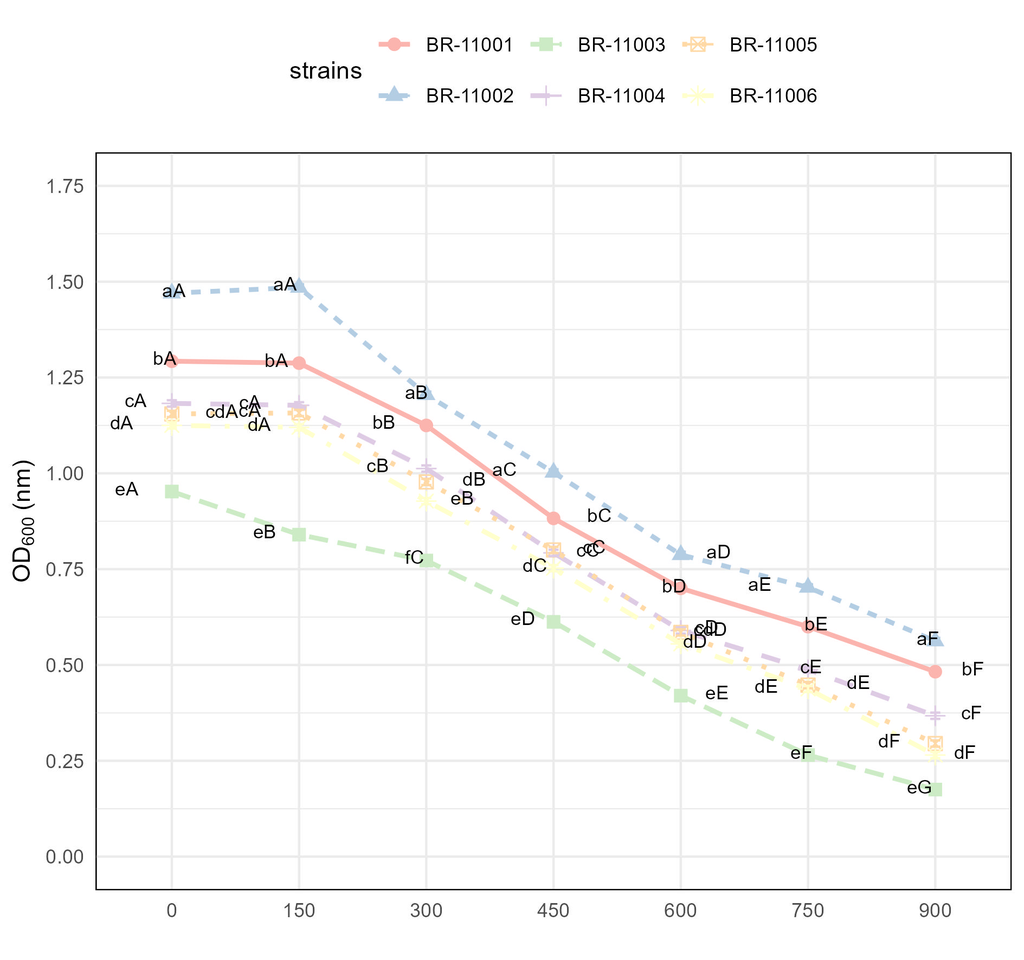

Figure 1: Optical density (OD₆₀₀) of A. brasilense strains grown in Luria–Bertani medium with NaCl concentrations ranging from 0 to 900 mM (n = 4). Error bars represent ± SE. Lowercase letters indicate differences among strains within each salinity level; uppercase letters indicate differences among NaCl levels within each strain (Tukey’s HSD, p < 0.05).

## *Germination dynamics and cotyledon emergence under salinity stress*

Germination behavior of *Chenopodium quinoa* was significantly influenced by both inoculation with *Azospirillum brasilense* and increasing NaCl concentrations. The two-way ANOVA showed highly significant main effects of strain, salinity level, and their interaction on all germination-related variables (p < 0.001, Figure 2).

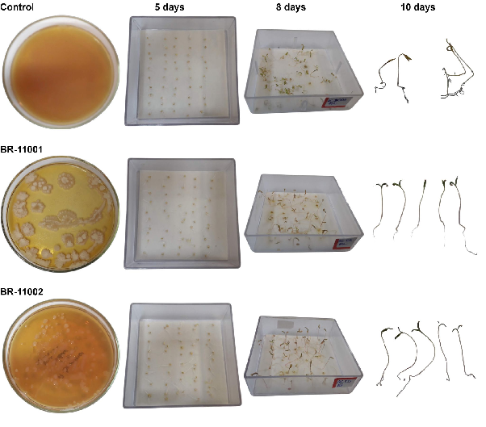

Figure 2: Visual comparison of Chenopodium quinoa germination and early seedling development under 300 mM NaCl at 5, 8, and 10 days after sowing. Treatments include: uninoculated control (seeds treated with sterile Luria–Bertani medium), inoculation with Azospirillum brasilense strain BR-11001, and BR-11002. Inoculated seeds - particularly BR-11002 - exhibited enhanced radicle emergence, shoot elongation, and seedling vigor.

Germination percentage remained unaffected by salinity up to 150 mM NaCl across all treatments, maintaining values of 100%. At 300 mM, a minor reduction was observed in the uninoculated control (95.5%), while BR-11001 and BR-11002 maintained high germination rates (98.5% and 99.0%, respectively). However, under 450 mM NaCl, germination was drastically reduced in the control to 52.5%, whereas BR-11001 and BR-11002 significantly mitigated this effect, maintaining germination at 78.5% and 84.0%, respectively (Figure 3a).

Germination uncertainty (GU) increased steadily with salinity. At 0 mM NaCl, BR-11001 and BR-11002 presented the lowest GU values (0.53 and 0.50), while the control exhibited a higher dispersion (0.77). At 450 mM, uncertainty increased to 2.91 in BR-11001, 2.83 in BR-11002, and 2.86 in the control, indicating reduced uniformity of germination events under high salinity (Figure 3 c).

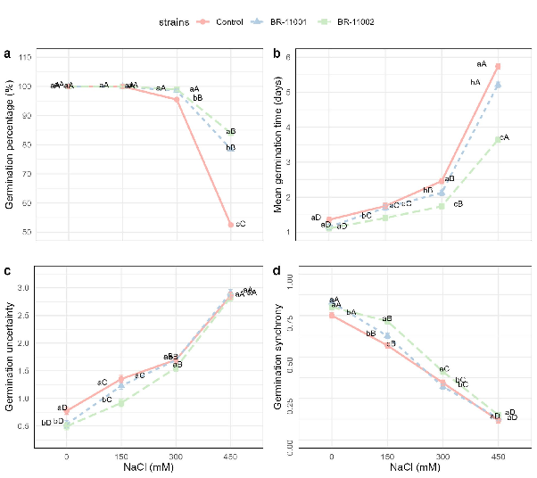

Figure 3: Germination responses of *C. quinoa* seeds inoculated with *A. brasilense* BR-11001 and BR-11002 under NaCl concentrations ranging from 0 to 450 mM (n = 4). (a) Germination percentage, (b) mean germination time, (c) germination uncertainty, and (d) germination synchrony. Error bars represent ± SE. Lowercase letters indicate differences among strains within each salinity level; uppercase letters indicate differences among NaCl levels within each strain (Tukey’s HSD, p < 0.05).

## *Seedling morphometric traits and biomass allocation*

Significant main effects of inoculation, salinity level, and their interaction (p < 0.001) were detected for all measured seedling parameters, including shoot length, root length, dry weight, and seedling vigor index (SVI) (Figure 4). Inoculation with *A. brasilense* strains BR-11001 and BR-11002 consistently enhanced seedling performance across all salinity treatments when compared to the uninoculated control.

Shoot length exhibited progressive reductions with increasing NaCl concentration, but the extent of decline was substantially mitigated by bacterial inoculation. Under non-saline conditions (0 mM), shoot length reached 6.03 cm and 5.81 cm in BR-11002 and BR-11001, respectively, compared to 4.77 cm in the control. At 450 mM NaCl, BR-11002 maintained a significantly greater shoot length (3.96 cm) than BR-11001 (3.06 cm) and the control (2.11 cm) (Figure 4 a)

Root length followed a similar pattern. At 0 mM, BR-11002 showed the highest value (3.93 cm), followed by BR-11001 (3.32 cm) and the control (3.05 cm). As salinity increased to 450 mM, root elongation declined in all treatments, with values of 2.54 cm (BR-11002), 2.10 cm (BR-11001), and 0.93 cm (control) (Figure 4 b)

Dry biomass accumulation was also significantly influenced by both salinity and inoculation. At 0 mM, BR-11002-treated seedlings produced the highest dry weight (0.049 g), outperforming BR-11001 (0.032 g) and the control (0.026 g). Even under severe salt stress (450 mM), BR-11002 maintained a superior biomass yield (0.0316 g), whereas BR-11001 and the control declined to 0.0258 g and 0.0185 g, respectively (Figure 4 c)

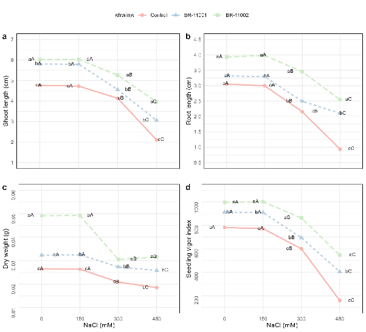

Figure 4: Morphometric traits of C. quinoa seedlings inoculated with A. brasilense BR-11001 and BR-11002 under NaCl stress. (a) Shoot length, (b) root length, (c) dry biomass, and (d) seedling vigor index. Data represent means ± SE (n = 4). Different lowercase letters denote significant differences among strains within each NaCl level; uppercase letters indicate differences among NaCl levels within each strain (Tukey’s HSD, p < 0.05).

## *Antioxidant enzyme activities in response to salt stress and inoculation*

The activities of all four antioxidant enzymes - superoxide dismutase (SOD), catalase (CAT), ascorbate peroxidase (APX), and guaiacol peroxidase (GPX) - were significantly affected by salinity, *A. brasilense* inoculation, and their interaction (p < 0.001,Figure 5).

Superoxide dismutase (SOD) activity increased with NaCl concentration in all treatments. At 0 mM, values were 23.96 U min⁻¹ mg⁻¹ protein in the control, 26.78 in BR-11001, and 26.67 in BR-11002. Under 450 mM, SOD activity reached 56.25 in the control, 63.36 in BR-11001, and peaked at 68.12 U min⁻¹ mg⁻¹ protein in BR-11002 (Figure 5 a).

Catalase (CAT) activity also showed an upward trend with increasing salinity. At 0 mM NaCl, CAT values were 14.15 (control), 14.94 (BR-11001), and 16.01 (BR-11002). Under 450 mM, CAT activity rose to 35.73 in the control, 41.70 in BR-11001, and 46.06 U min⁻¹ mg⁻¹ protein in BR-11002 (Figure 5 b).

Ascorbate peroxidase (APX) activity followed a similar pattern. At 0 mM, the control registered 9.36, while BR-11001 and BR-11002 recorded 10.84 and 10.76, respectively. At 450 mM, APX values reached 25.59 (control), 29.64 (BR-11001), and 33.05 U min⁻¹ mg⁻¹ protein (BR-11002) (Figure 5 c).

Guaiacol peroxidase (GPX) activity was lowest under non-saline conditions, with values of 7.15 in the control, 7.93 in BR-11001, and 7.62 in BR-11002. At 450 mM NaCl, GPX activity increased to 17.78 (control), 20.86 (BR-11001), and 23.38 U min⁻¹ mg⁻¹ protein in BR-11002 (Figure 5 d).

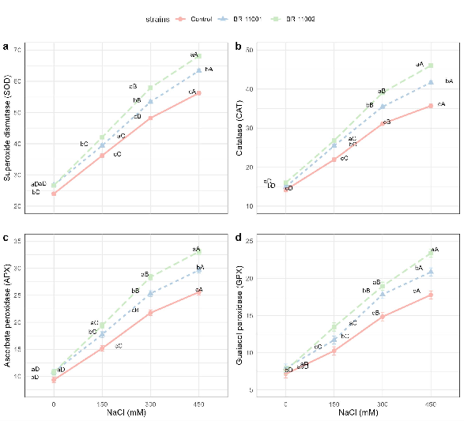

Figure 5: Antioxidant enzyme activity of Chenopodium quinoa seedlings subjected to salinity stress and inoculation with A. brasilense strains BR-11001 and BR-11002. (a) Superoxide dismutase (SOD), (b) catalase (CAT), (c) ascorbate peroxidase (APX), and (d) guaiacol peroxidase (GPX). Enzyme activities are expressed as U min⁻¹ mg⁻¹ protein. Values represent means ± SE (n = 4). Different lowercase letters indicate significant differences among strains within each salinity level, and uppercase letters denote differences among salinity levels within each strain (Tukey’s HSD, p < 0.05).

# **Discussion**

The present study underscores the potential of *Azospirillum brasilense*, particularly strain BR-11002, to improve early-stage salinity tolerance in *Chenopodium quino*a through a multifaceted suite of mechanisms, including enhanced germination, seedling growth, and antioxidant responses. These results support the emerging role of halotolerant plant growth-promoting bacteria (PGPB) in developing sustainable strategies to mitigate abiotic stress in crops [(Hernández-Canseco *et al.*, 2022; Degon *et al.*, 2023)](https://www.zotero.org/google-docs/?3SmYar). Recent studies confirm that inoculation with halotolerant PGPB can alleviate salt-induced damage by modulating hormonal signaling, enhancing ion and nutrient uptake, and activating antioxidative pathways [(Baek *et al.*, 2020; Degon *et al.*, 2023; Liu *et al.*, 2025)](https://www.zotero.org/google-docs/?OIZUz1).

Germination dynamics were significantly stabilized under saline conditions by bacterial inoculation. Seeds treated with BR-11002 maintained germination rates above 84% at 450 mM NaCl, while the uninoculated control dropped to 52.5%. This marked enhancement under osmotic stress reflects the capacity of *A. brasilense* to facilitate early water uptake, protect membrane integrity, and maintain cellular turgor - mechanisms also observed in cereals and legumes inoculated with PGPB [(Caires *et al.*, 2021; Mattos, Valgas and Martins, 2022; Terra, Rezende and Florentino, 2023; Cunha *et al.*, 2024)](https://www.zotero.org/google-docs/?Kq4v4A). Moreover, reduced mean germination time (MGT) and germination uncertainty (GU), along with increased synchrony, suggest that inoculated seeds benefit from a more coordinated and efficient germination process - crucial for uniform field emergence under stress-prone conditions.

Beyond germination, seedling development was also markedly improved. Inoculated seedlings exhibited significantly longer shoot and root lengths, higher dry biomass, and enhanced seedling vigor indices across all salinity levels. These findings are consistent with previous reports demonstrating that *A. brasilense* promotes vegetative growth through phytohormone production (especially IAA), improved ion homeostasis, and stimulation of lateral root development [(Spaepen *et al.*, 2008; Da Silva *et al.*, 2022; Neshat *et al.*, 2022; Zaheer *et al.*, 2022)](https://www.zotero.org/google-docs/?CP8Jh2). Such enhancements contribute to greater resource acquisition and physiological stability, giving seedlings a competitive advantage during the critical early stages of establishment under saline conditions.

The biochemical response further confirmed the functional role of *A. brasilense* in stress mitigation. Inoculated seedlings, particularly those treated with BR-11002, displayed significantly elevated activity of key antioxidant enzymes - SOD, CAT, APX, and GPX -especially at 300 and 450 mM NaCl. These enzymes constitute the core of the ROS-detoxifying system and are essential for preserving membrane integrity and protein function during abiotic stress [(Hasanuzzaman *et al.*, 2021; Zandi and Schnug, 2022; Kesawat *et al.*, 2023)](https://www.zotero.org/google-docs/?QdxAur). Comparable enzymatic enhancement has been observed in soybean and tomato inoculated with stress-tolerant bacteria, where improved antioxidant profiles were linked to reduced lipid peroxidation and better photosynthetic performance [(Aleem *et al.*, 2022; Nurbekova *et al.*, 2024; Patel *et al.*, 2024; Ansari *et al.*, 2025)](https://www.zotero.org/google-docs/?ugtffH).

These physiological and biochemical responses are likely governed by a complex interplay between microbial traits and plant regulatory pathways. Beneficial rhizobacteria such as *A. brasilense* are known to synthesize exopolysaccharides, osmoprotectants, and hormones that prime plants for stress resistance. In parallel, host plants activate transcriptional responses that reinforce antioxidant defenses and facilitate ion compartmentalization. Transcriptomic analyses in rice and wheat have demonstrated that *A. brasilense* inoculation upregulates genes involved in ABA signaling, redox homeostasis, and ion transport under salt stress [(Sah, Reddy and Li, 2016; Huang *et al.*, 2021; Degon *et al.*, 2023)](https://www.zotero.org/google-docs/?CHq7ob). For instance, [(Huang *et al.*, 2021)](https://www.zotero.org/google-docs/?B7WyWs) showed that ABA accumulation under salinity modifies root meristem activity and cell expansion, a process modulated by bacterial inoculation through hormonal crosstalk. Although gene expression was not directly assessed in the present study, the observed phenotypic and biochemical responses strongly suggest that analogous regulatory mechanisms were activated in quinoa.  
In light of the expanding prevalence of salt-affected soils and the rising global interest in quinoa as a resilient and nutritious crop, the use of *A. brasilense* strain BR-11002 as a bioinoculant presents a promising and eco-compatible strategy. The consistent improvements across germination, seedling vigor, and antioxidant capacity highlight the strain’s versatility and potential scalability in saline agroecosystems. These findings support the integration of halotolerant PGPB into sustainable agriculture frameworks aimed at enhancing crop performance in degraded and marginal lands.

# **Conclusion**

This study demonstrates that inoculation with halotolerant *Azospirillum brasilense,* especially strain BR-11002, significantly enhances germination performance, early seedling development, and antioxidant enzyme activity in *Chenopodium quinoa* under saline conditions. The consistent improvements observed across physiological and biochemical parameters affirm the potential of BR-11002 as an effective bioinoculant for promoting quinoa establishment in salt-affected soils. These findings lay the groundwork for incorporating halotolerant plant growth-promoting bacteria into sustainable farming systems designed to enhance crop tolerance and performance under saline or resource-limited conditions.

**Author Contributions:** Conception and design of the study by JDAC, RPR, and RJSS. Material preparation, data collection, and analysis were performed by JDAC, MNMS, and FLI. The first draft of the manuscript was written by JDAC, MNMS, FLI, RPR and RJSS contributed to the review and editing of the manuscript. RPR also supervised the study and acquired the funded for the APC. All authors read and approved the final manuscript.

**Funding:** This research received no external funding, and the APC was funded by Universidade Estadual de Santa Cruz (UESC).

**Data Availability Statement:** The data presented in this study are available upon request from the corresponding author.

**Acknowledgments:** We express our gratitude to the Microbial Biotechnology Laboratory and the LaBiOmicas Laboratory of the Center for Biotechnology and Genetics at UESC for providing the necessary resources, technical support, and infrastructure for this research.

**Conflicts of Interest:** The authors declare no conflicts of interest.

# **References**

[Aebi, H. (1984) “[13] Catalase in vitro,” in *Methods in Enzymology*. Elsevier, pp. 121–126. Available at: https://doi.org/10.1016/S0076-6879(84)05016-3.](https://www.zotero.org/google-docs/?B62rzm)

[Aleem, Muqadas *et al.* (2022) “Characterization of SOD and GPX Gene Families in the Soybeans in Response to Drought and Salinity Stresses,” *Antioxidants*, 11(3), p. 460. Available at: https://doi.org/10.3390/antiox11030460.](https://www.zotero.org/google-docs/?B62rzm)

[Ansari, W.A. *et al.* (2025) “Multifaceted Rhizobacterial Co‐Inoculation Enhances Drought‐Stress Tolerance in Tomato: Insights Into Physiological, Biochemical, and Molecular Responses,” *Journal of Basic Microbiology* [Preprint]. Available at: https://doi.org/10.1002/jobm.70065.](https://www.zotero.org/google-docs/?B62rzm)

[Baek, D. *et al.* (2020) “Plant-Growth Promoting *Bacillus oryzicola* YC7007 Modulates Stress-Response Gene Expression and Provides Protection From Salt Stress,” *Frontiers in Plant Science*, 10. Available at: https://doi.org/10.3389/fpls.2019.01646.](https://www.zotero.org/google-docs/?B62rzm)

[Barbieri, G.F. *et al.* (2019) “Seed Germination and Initial Growth of Quinoa Seedlings Under Water and Salt Stress,” *Journal of Agricultural Science*, 11(15), p. 153. Available at: https://doi.org/10.5539/jas.v11n15p153.](https://www.zotero.org/google-docs/?B62rzm)

[Bates, D. *et al.* (2015) “Fitting Linear Mixed-Effects Models Using *lme4*,” *Journal of Statistical Software*, 67(1). Available at: https://doi.org/10.18637/jss.v067.i01.](https://www.zotero.org/google-docs/?B62rzm)

[Bazile, D., Jacobsen, S.-E. and Verniau, A. (2016) “The Global Expansion of Quinoa: Trends and Limits,” *Frontiers in Plant Science*, 7. Available at: https://doi.org/10.3389/fpls.2016.00622.](https://www.zotero.org/google-docs/?B62rzm)

[Caires, E.F. *et al.* (2021) “Seed inoculation with *Azospirillum brasilense* and nitrogen fertilization for no‐till cereal production,” *Agronomy Journal*, 113(1), pp. 560–576. Available at: https://doi.org/10.1002/agj2.20488.](https://www.zotero.org/google-docs/?B62rzm)

[Causin, H.F., Bordón, D.A.E. and Burrieza, H. (2020) “Salinity tolerance mechanisms during germination and early seedling growth in *Chenopodium quinoa* Wild. genotypes with different sensitivity to saline stress,” *Environmental and Experimental Botany*, 172, p. 103995. Available at: https://doi.org/10.1016/j.envexpbot.2020.103995.](https://www.zotero.org/google-docs/?B62rzm)

[Costa, P.S. *et al.* (2024) “Seed priming with light quality and Cyperus rotundus L. extract modulate the germination and initial growth of Moringa oleifera Lam. seedlings,” *Brazilian Journal of Biology*, 84. Available at: https://doi.org/10.1590/1519-6984.255836.](https://www.zotero.org/google-docs/?B62rzm)

[Cunha, V.D.S. *et al.* (2024) “Promoting black oat and ryegrass growth via *Azospirillum brasilense* inoculation after corn and soybean crop rotation,” *Emirates Journal of Food and Agriculture*, 36, pp. 1–8. Available at: https://doi.org/10.3897/ejfa.2024.118453.](https://www.zotero.org/google-docs/?B62rzm)

[Da Cunha, E.T., Pedrolo, A.M. and Arisi, A.C.M. (2024) “Thermal and salt stress effects on the survival of plant growth‐promoting bacteria *Azospirillum brasilense* in inoculants for maize cultivation,” *Journal of the Science of Food and Agriculture*, 104(9), pp. 5360–5367. Available at: https://doi.org/10.1002/jsfa.13366.](https://www.zotero.org/google-docs/?B62rzm)

[Da Silva, M.S.R.D.A. *et al.* (2022) “Stimulatory effects of defective and effective 3-indoleacetic acid-producing bacterial strains on rice in an advanced stage of its vegetative cycle,” *Brazilian Journal of Microbiology*, 53(1), pp. 281–288. Available at: https://doi.org/10.1007/s42770-021-00651-8.](https://www.zotero.org/google-docs/?B62rzm)

[Degon, Z. *et al.* (2023) “*Azospirillum brasilense* improves rice growth under salt stress by regulating the expression of key genes involved in salt stress response, abscisic acid signaling, and nutrient transport, among others,” *Frontiers in Agronomy*, 5. Available at: https://doi.org/10.3389/fagro.2023.1216503.](https://www.zotero.org/google-docs/?B62rzm)

[Dias, G.F. *et al.* (2025) “Seed Priming with PEG 6000 and Silicic Acid Enhances Drought Tolerance in Cowpea by Modulating Physiological Responses,” *Horticulturae*, 11(4), p. 438. Available at: https://doi.org/10.3390/horticulturae11040438.](https://www.zotero.org/google-docs/?B62rzm)

[Egamberdieva, D. *et al.* (2017) “Phytohormones and Beneficial Microbes: Essential Components for Plants to Balance Stress and Fitness,” *Frontiers in Microbiology*, 8, p. 2104. Available at: https://doi.org/10.3389/fmicb.2017.02104.](https://www.zotero.org/google-docs/?B62rzm)

[FAO (2021) “Global map of salt-affected soils,” p. 20.](https://www.zotero.org/google-docs/?B62rzm)

[Hasanuzzaman, M. *et al.* (2021) “Regulation of Reactive Oxygen Species and Antioxidant Defense in Plants under Salinity,” *International Journal of Molecular Sciences*, 22(17), p. 9326. Available at: https://doi.org/10.3390/ijms22179326.](https://www.zotero.org/google-docs/?B62rzm)

[Hernández-Canseco, J. *et al.* (2022) “Plant Growth-Promoting Halobacteria and Their Ability to Protect Crops from Abiotic Stress: An Eco-Friendly Alternative for Saline Soils,” *Agronomy*, 12(4), p. 804. Available at: https://doi.org/10.3390/agronomy12040804.](https://www.zotero.org/google-docs/?B62rzm)

[Huang, Y. *et al.* (2021) “Salt Stress Promotes Abscisic Acid Accumulation to Affect Cell Proliferation and Expansion of Primary Roots in Rice,” *International Journal of Molecular Sciences*, 22(19), p. 10892. Available at: https://doi.org/10.3390/ijms221910892.](https://www.zotero.org/google-docs/?B62rzm)

[Hungria, M. *et al.* (2010) “Inoculation with selected strains of *Azospirillum brasilense* and *A. lipoferum* improves yields of maize and wheat in Brazil,” *Plant and Soil*, 331(1–2), pp. 413–425. Available at: https://doi.org/10.1007/s11104-009-0262-0.](https://www.zotero.org/google-docs/?B62rzm)

[ISTA (2022) *International Rules Seed Testing | Official ISTA Guidelines*, *International Seed Testing Association*. Available at: https://www.seedtest.org/en/publications/international-rules-seed-testing.html (Accessed: July 9, 2025).](https://www.zotero.org/google-docs/?B62rzm)

[Kerbab, S. *et al.* (2021) “Mitigation of NaCl Stress in Wheat by Rhizosphere Engineering Using Salt Habitat Adapted PGPR Halotolerant Bacteria,” *Applied Sciences*, 11(3), p. 1034. Available at: https://doi.org/10.3390/app11031034.](https://www.zotero.org/google-docs/?B62rzm)

[Kesawat, M.S. *et al.* (2023) “Regulation of Reactive Oxygen Species during Salt Stress in Plants and Their Crosstalk with Other Signaling Molecules—Current Perspectives and Future Directions,” *Plants*, 12(4), p. 864. Available at: https://doi.org/10.3390/plants12040864.](https://www.zotero.org/google-docs/?B62rzm)

[Khumairah, F.H. *et al.* (2022) “Halotolerant Plant Growth-Promoting Rhizobacteria Isolated From Saline Soil Improve Nitrogen Fixation and Alleviate Salt Stress in Rice Plants,” *Frontiers in Microbiology*, 13, p. 905210. Available at: https://doi.org/10.3389/fmicb.2022.905210.](https://www.zotero.org/google-docs/?B62rzm)

[Lenth, R.V. (2017) “emmeans: Estimated Marginal Means, aka Least-Squares Means.” Available at: https://doi.org/10.32614/CRAN.package.emmeans.](https://www.zotero.org/google-docs/?B62rzm)

[Liu, H. *et al.* (2025) “Bacillus amyloliquefaciens strain Q1 inoculation enhances salt tolerance of barley seedlings by maintaining the photosynthetic capacity and intracellular Na+/K+ homeostasis,” *Plant Growth Regulation*, 105(1), pp. 111–128. Available at: https://doi.org/10.1007/s10725-024-01260-9.](https://www.zotero.org/google-docs/?B62rzm)

[Lozano‐Isla, F., Benites‐Alfaro, O.E. and Pompelli, M.F. (2019) “GerminaR: An R package for germination analysis with the interactive web application ‘GerminaQuant for R,’” *Ecological Research*, 34(2), pp. 339–346. Available at: https://doi.org/10.1111/1440-1703.1275.](https://www.zotero.org/google-docs/?B62rzm)

[Mattos, M.L.T., Valgas, R.A. and Martins, J.F.D.S. (2022) “Evaluation of the Agronomic Efficiency of *Azospirillum brasilense* Strains Ab-V5 and Ab-V6 in Flood-Irrigated Rice,” *Agronomy*, 12(12), p. 3047. Available at: https://doi.org/10.3390/agronomy12123047.](https://www.zotero.org/google-docs/?B62rzm)

[Mougiou, N. *et al.* (2018) “Expression of hydroxytyrosol and oleuropein biosynthetic genes are correlated with metabolite accumulation during fruit development in olive, Olea europaea , cv. Koroneiki,” *Plant Physiology and Biochemistry*, 128, pp. 41–49. Available at: https://doi.org/10.1016/j.plaphy.2018.05.004.](https://www.zotero.org/google-docs/?B62rzm)

[Neshat, M. *et al.* (2022) “Plant growth promoting bacteria (PGPR) induce antioxidant tolerance against salinity stress through biochemical and physiological mechanisms,” *Physiology and Molecular Biology of Plants*, 28(2), pp. 347–361. Available at: https://doi.org/10.1007/s12298-022-01128-0.](https://www.zotero.org/google-docs/?B62rzm)

[Nurbekova, Z. *et al.* (2024) “Strategies for Achieving High and Sustainable Plant Productivity in Saline Soil Conditions,” *Horticulturae*, 10(8), p. 878. Available at: https://doi.org/10.3390/horticulturae10080878.](https://www.zotero.org/google-docs/?B62rzm)

[de Oliveira Vergara, R. *et al.* (2019) “Plant growth and physiological quality of quinoa (’Chenopodium quinoa’Willd) seeds grown in Southern Rio Grande do Sul, Brazil,” *Australian Journal of Crop Science*, 13(5), pp. 678–682.](https://www.zotero.org/google-docs/?B62rzm)

[Omar, M.N.A. *et al.* (2009) “Improvement of salt tolerance mechanisms of barley cultivated under salt stress using Azospirillum brasiliense. Tasks Veg Sci 44: 133–147.”](https://www.zotero.org/google-docs/?B62rzm)

[Patel, M. *et al.* (2024) “Elaborating the multifarious role of PGPB for sustainable food security under changing climate conditions,” *Microbiological Research*, 289, p. 127895. Available at: https://doi.org/10.1016/j.micres.2024.127895.](https://www.zotero.org/google-docs/?B62rzm)

[R Core Team (2024) “R: A Language and Environment for Statistical Computing.” Vienna, Austria: R Foundation for Statistical Computing. Available at: https://www.r-project.org/.](https://www.zotero.org/google-docs/?B62rzm)

[Ranal, M.A. and Santana, D.G.D. (2006) “How and why to measure the germination process?,” *Revista Brasileira de Botânica*, 29(1), pp. 1–11. Available at: https://doi.org/10.1590/s0100-84042006000100002.](https://www.zotero.org/google-docs/?B62rzm)

[Reis, V.M. *et al.* (2001) “Biological nitrogen fixation associated with tropical pasture grasses,” *Functional Plant Biology*, 28(9), p. 837. Available at: https://doi.org/10.1071/pp01079.](https://www.zotero.org/google-docs/?B62rzm)

[Rekik, I. *et al.* (2017) “Effects of untreated and treated wastewater at the morphological, physiological and biochemical levels on seed germination and development of sorghum (*Sorghum bicolor* (L.) Moench), alfalfa (*Medicago sativa* L.) and fescue (*Festuca arundinacea* Schreb.),” *Journal of Hazardous Materials*, 326, pp. 165–176. Available at: https://doi.org/10.1016/j.jhazmat.2016.12.033.](https://www.zotero.org/google-docs/?B62rzm)

[Sah, S.K., Reddy, K.R. and Li, J. (2016) “Abscisic Acid and Abiotic Stress Tolerance in Crop Plants,” *Frontiers in Plant Science*, 7. Available at: https://doi.org/10.3389/fpls.2016.00571.](https://www.zotero.org/google-docs/?B62rzm)

[Sampaio, S.L. *et al.* (2020) “Nutritional value, physicochemical characterization and bioactive properties of the Brazilian quinoa BRS Piabiru,” *Food & Function*, 11(4), pp. 2969–2977.](https://www.zotero.org/google-docs/?B62rzm)

[Santos, A.P. *et al.* (2023) “Extremophiles as Plant Probiotics to Promote Germination and Alleviate Salt Stress in Soybean,” *Journal of Plant Growth Regulation*, 42(2), pp. 946–959. Available at: https://doi.org/10.1007/s00344-022-10605-5.](https://www.zotero.org/google-docs/?B62rzm)

[Shrivastava, P. and Kumar, R. (2015) “Soil salinity: A serious environmental issue and plant growth promoting bacteria as one of the tools for its alleviation,” *Saudi Journal of Biological Sciences*, 22(2), pp. 123–131. Available at: https://doi.org/10.1016/j.sjbs.2014.12.001.](https://www.zotero.org/google-docs/?B62rzm)

[Siṃha, Ś.P., Sinha, R.P. and Häder, D.P. (eds.) (2024) *Methods in Cyanobacterial Research*. First edition. Boca Raton: CRC Press, Taylor & Francis Group. Available at: https://doi.org/10.1201/9781003398387.](https://www.zotero.org/google-docs/?B62rzm)

[Spaepen, S. *et al.* (2008) “Effects of *Azospirillum brasilense* indole-3-acetic acid production on inoculated wheat plants,” *Plant and Soil*, 312(1–2), pp. 15–23. Available at: https://doi.org/10.1007/s11104-008-9560-1.](https://www.zotero.org/google-docs/?B62rzm)

[Terra, A.B.C., Rezende, A.V.D. and Florentino, L.A. (2023) “Co-inoculation with *Azospirillum brasilense* promotes growth in forage legumes,” *Revista Ceres*, 70(5). Available at: https://doi.org/10.1590/0034-737x202370050014.](https://www.zotero.org/google-docs/?B62rzm)

[Zaheer, M.S. *et al.* (2022) “Cytokinin Production by *Azospirillum brasilense* Contributes to Increase in Growth, Yield, Antioxidant, and Physiological Systems of Wheat (*Triticum aestivum* L.),” *Frontiers in Microbiology*, 13. Available at: https://doi.org/10.3389/fmicb.2022.886041.](https://www.zotero.org/google-docs/?B62rzm)

[Zandi, P. and Schnug, E. (2022) “Reactive Oxygen Species, Antioxidant Responses and Implications from a Microbial Modulation Perspective,” *Biology*, 11(2), p. 155. Available at: https://doi.org/10.3390/biology11020155.](https://www.zotero.org/google-docs/?B62rzm)

[Zhao, X., Joo, J.C. and Kim, J.Y. (2021) “Evaluation of heavy metal phytotoxicity to Helianthus annuus L. using seedling vigor index-soil model,” *Chemosphere*, 275, p. 130026. Available at: https://doi.org/10.1016/j.chemosphere.2021.130026.](https://www.zotero.org/google-docs/?B62rzm)

[Zörb, C., Geilfus, C. ‐M. and Dietz, K. ‐J. (2019) “Salinity and crop yield,” *Plant Biology*. Edited by A. Weber, 21(S1), pp. 31–38. Available at: https://doi.org/10.1111/plb.12884.](https://www.zotero.org/google-docs/?B62rzm)